# What drives the functional response to disturbance in Paracou?

# Data visualisation

## Traits trajectory

Traits chosen:

- $DBH95$: DBH 95th percentile (per species) as a proxy of the stature
- $logSeedMass$: median seed mass (log-transformed) as a proxy of the dispersal strategy
- $SLA$: median specific leaf area, as a proxy of the assimilation strategy and leaf economic spectrum
- $WD$: median wood density, as a proxy of growth rate and mechanical support

Cohorts:

- Survivors, ie trees that survived logging
- Recruits, ie trees that passed the 10 cm DBH threshold after logging

Here are represented for each cohort the mean trait value, weighted by the estimated above ground biomass (AGB) of each individual.

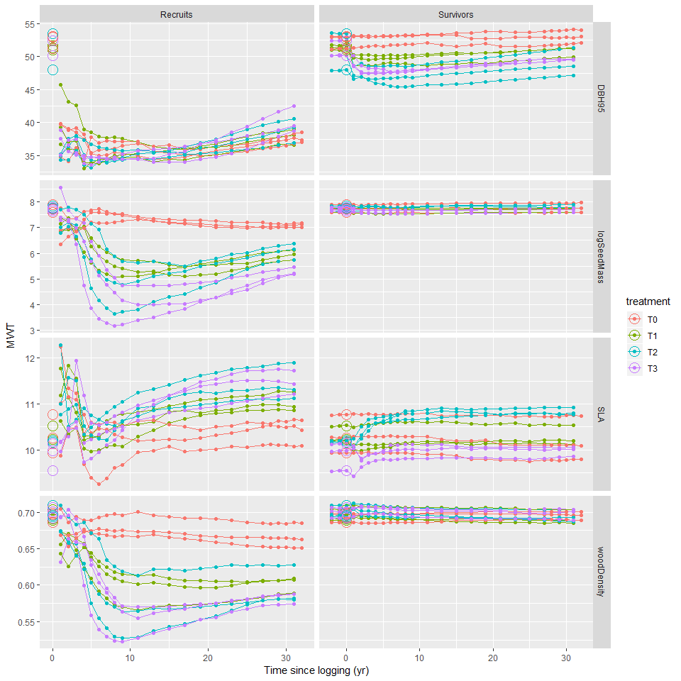

For $D$: there seems to be no effect of logging gaps on recruitment, the only effect is on survivors (direct removal of big trees + higher growth rates of big survivors): worth including in the study?

We can exclude $D$ from the study later.

## Recruits most common genuses and their impact on mean weighted traits

### AGB per genus

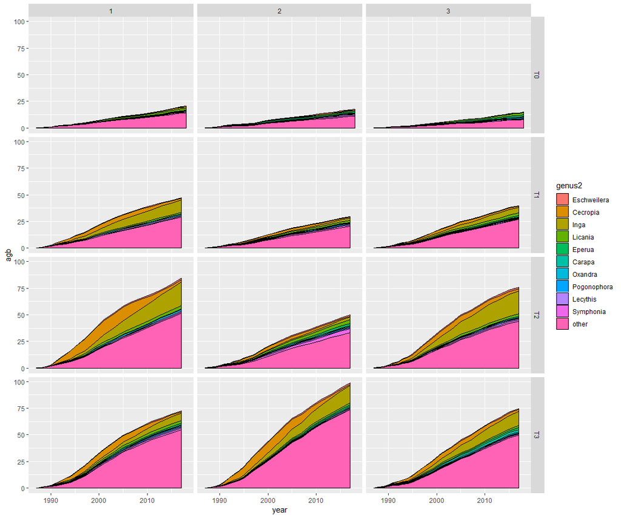

### Proportion of total AGB

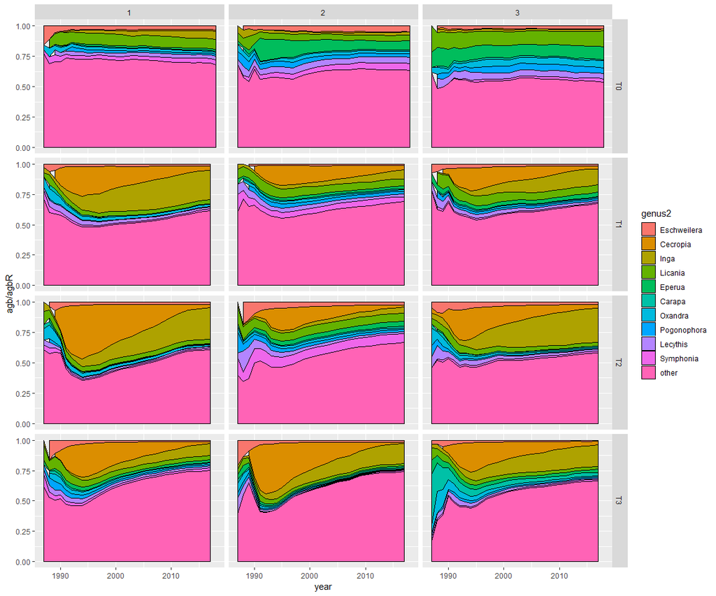

### Seed mass (log-transformed)

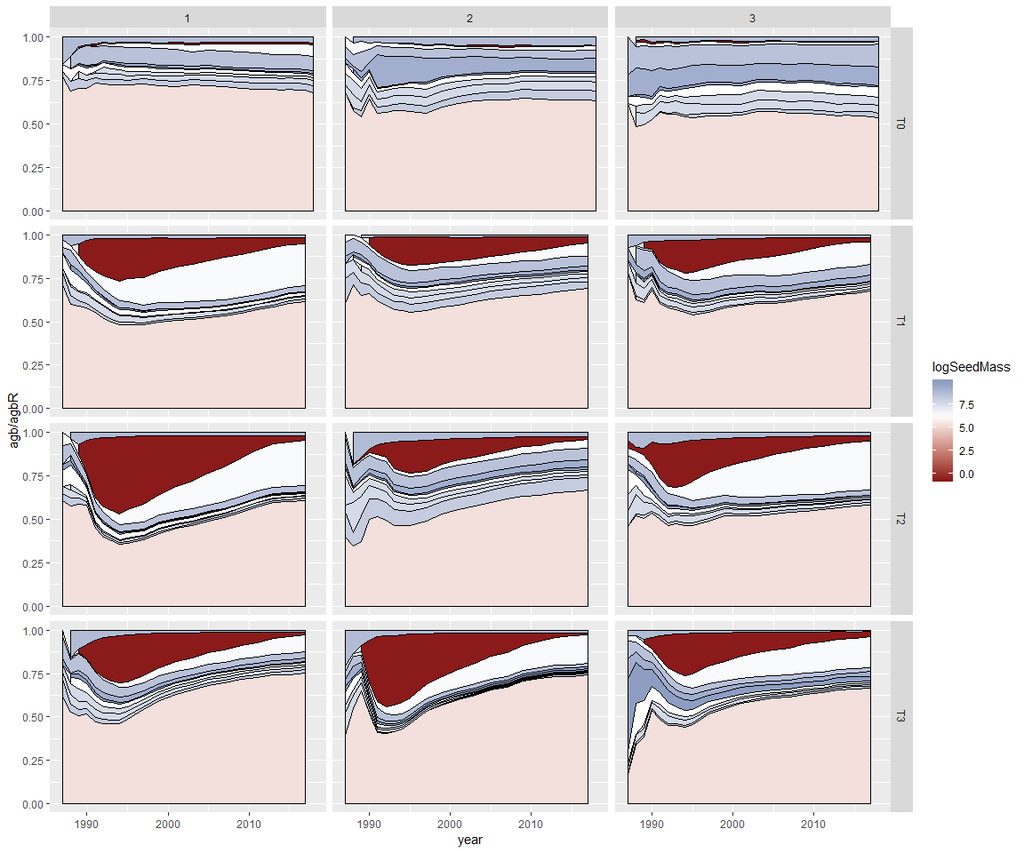

### SLA

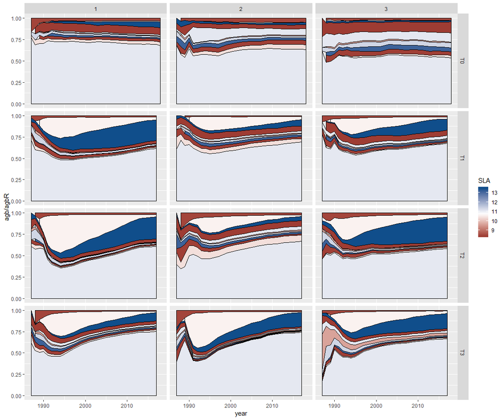

### Wood Density

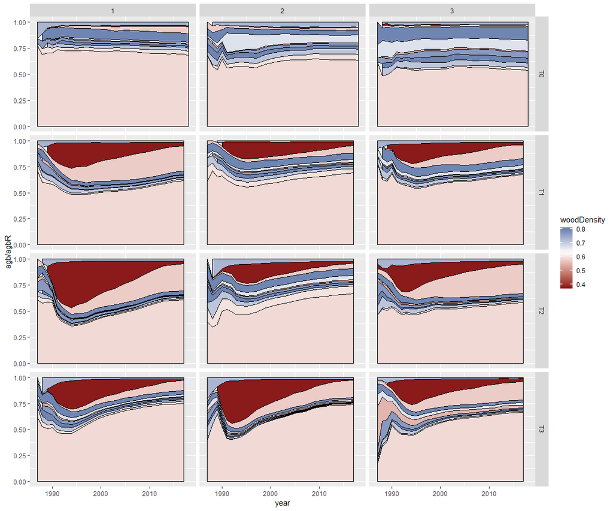

### Conclusions

Early pioneer = cecropias (SLA 0 // seed mass – // WD – )

Late pioneer = ingas + miconias + tapiriras + vismias (SLA ++ // seed mass - // WD - )

## What can explain survivors’ changes in WMT? (especially with SLA)

### Logging direct effect

Here we investigate the WMT of trees killed during logging operations and compare it to the community WMT.

The categories are:

- “logged”: trees intentionally logged
- “devitalized”: big trees intentionally poisoned and girdled
- “damage”: non-intentional damage caused by logging operations (skid trails opening, tree felling) / should be random but affects smaller trees more, which have a slightly different functional composition

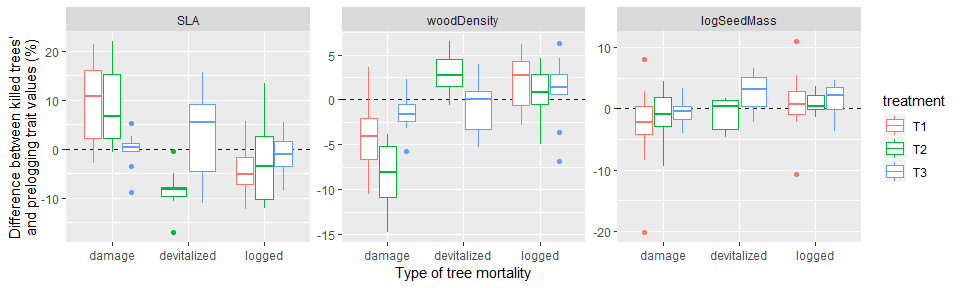

### Post-logging survivors dynamics

Here we analyse the WMT of the additional biomass from survivors’ growth and the WMT of survivors’ mortality, to see if some patterns in survivors dynamics can explain the changes in survivors’ traits.

$$WMTGrowth_{c} = \frac{\sum_{i\in I_{c-1} \cap I_{c}} (dG_{i,c} \cdot TR_i)}{\sum_{i\in I_{c-1} \cap I_{c}} (dG_{i,c})}$$

with $I_{c-1} \cap I_{c}$ the set of trees alive at both censuses $c-1$ and $c$, $dG_{i,c}$ the above-ground biomass gain of tree $i$ between census $c-1$ and $c$, and $TR_i$ the trait value of tree $i$.

$$WMTMort_{c} = \frac{\sum_{i\in I_{c-1} \setminus I_{c}} (agb_{i,c-1} \cdot TR_i)}{\sum_{i\in I_{c-1} \setminus I_{c}} (agb_{i,c-1})}$$
with $I_{c-1} \setminus I_{c}$ the set of trees alive at censuses $c-1$ and dead at $c$, $agb_{i,c-1}$ the above ground biomass gain of tree $i$ at census $c-1$, and $TR_i$ the trait value of tree $i$.

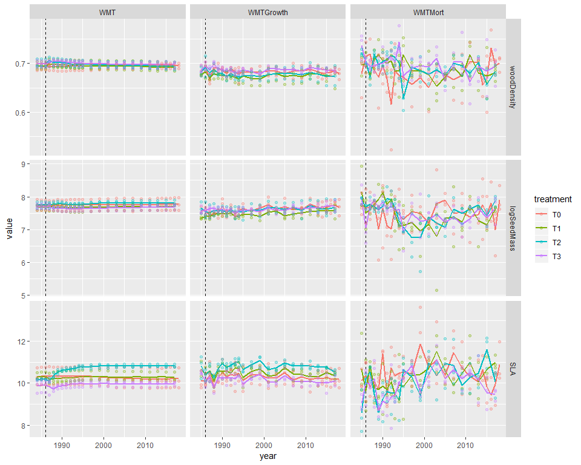

**Conclusions**

The mortality of survivors during silvilcultural treatments (1987-1990) targetted trees with low SLA in treatments T2 and T3, as seen previously, but then the mortality is not different from other treatments (T0: control and T1: conventional logging).

Survivors’ growth seems to be slightly higher for high-SLA species in treatment T2, maybe because the biggest trees that were left after silvicultural treatments had higher-than-average SLA. This difference is however not very strong.

# Recruits modelling

For each trait $k$, the mean recruits mean weighted trait (RMWT) trajectory in plot $p$ was modelled as:

$$TR_{k,p,c} = \underbrace{TR0_{k,p}}_{\text{pre-logging value}}\left(1 + \underbrace{\left(\Delta_{k,p} \cdot \frac{t_c}{tmax_{k,p}} \cdot exp\left(1-\frac{t_c}{tmax_{k,p}}\right)\right)^{\theta_k}}_{\text{boom and bust pattern}} \right)$$

with

- $c$ the census, and $t_c$ the time since logging (in years) at census $c$,
- $TR0_{k,p}$ the pre-logging trait value of the community in plot $p$.
- $\Delta_{k,p}$ is the maximum value (relative to the final value) of the hump that follows logging and the creation of logging gaps. $\Delta_{k,p} = 0$ for control plots and $\Delta_{k,p} \sim \mathcal{N} (\mu_{\Delta k}, \sigma_{\Delta}^2)$ in logged plots, with $\mu_{\Delta k}$ and $\sigma_{\Delta}$ are respectively the mean and standard deviation of $\Delta$ for trait $k$.
- $tmax_{k,p}$ is the time when the maximum value of the hump is reached. $tmax_{k,p} = 0$ for control plots and in logged plots $tmax_{k,p} \sim \mathcal{N} (\mu m_{ k}, \sigma m^2)$ where $\mu m_{k}$ and $\sigma m$ are respectively the mean and standard deviation of $tmax$ for trait $k$.
- $\theta_k$ is a shape parameter that controls the width of the hump; when it increases, the hump is narrower.

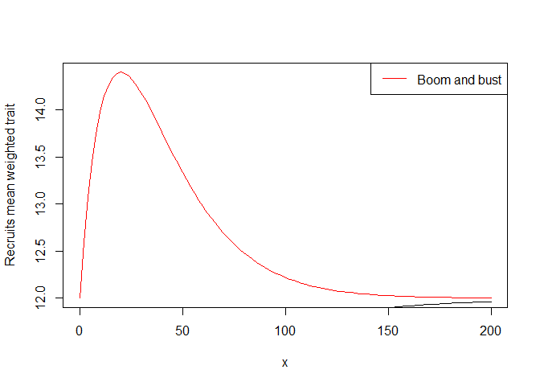

## Plotting predictions

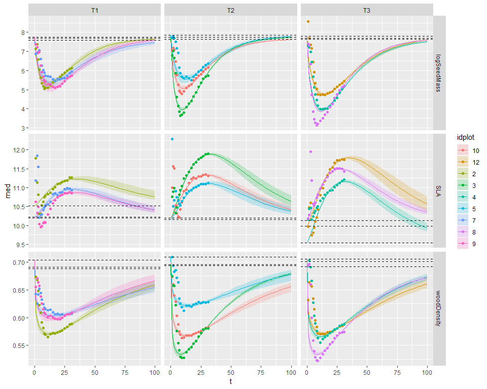

## Exploring parameters values

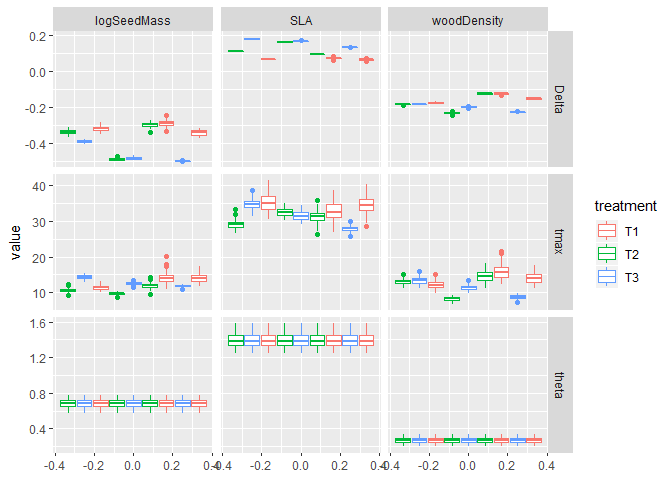

**tmax** for the seed mass and wood density, the “boom and bust” pattern is primarly driven by early pioneers (cecropias), so tmax is around 12 years. For SLA, cecropias have a rather average SLA (around 11 m2/kg) but secondary pioneers like ingas exhibit high SLA values: the boom-and-bust pattern is thus driven by the dynamics of this second group of pioneers, and is around 30 years.

One possibility is to set only one $tmax$ per trait and site, reflecting the local dynamics of pioneers according to their trait value. This could be interesting

### Delta

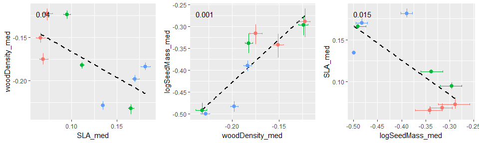

Strong correlation between $\Delta$ for wood densty and seed mass: linked by the max density of cecropias.

$\Delta$ for SLA correlates less but still strongly with other traits: logging intensity effect?

### Effect of logging intensity

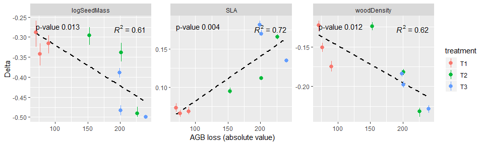

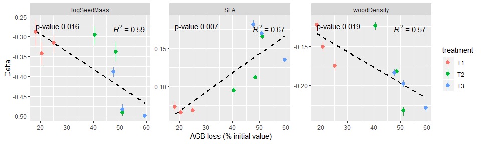

Neat correlation between the amount of AGB loss after logging operations and the maximum trait value reached after logging.

$\rightarrow$ add as covariable

### Effect of initial composition in recruits’ trajectory

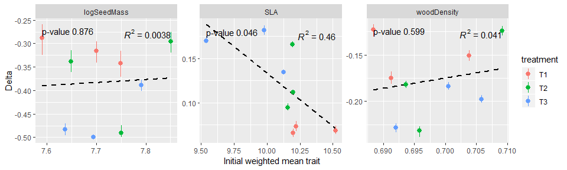

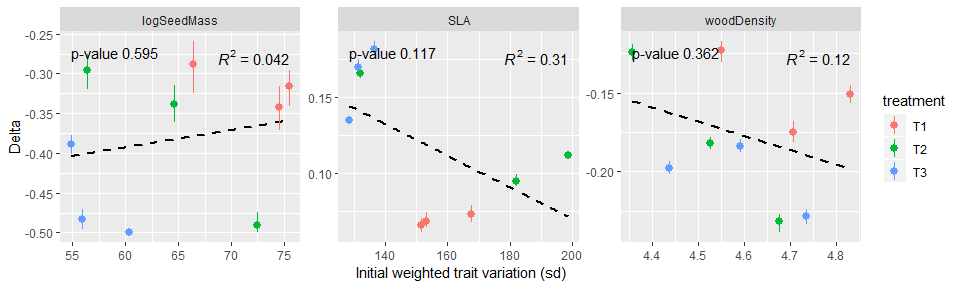

**Conclusion** The pre-logging functional composition does not seem to impact significantly the post-logging trajectory in Paracou.

## New recruits modelling: with 2 cohorts (test)

$$TR_{k,p,c} = \underbrace{TR0_{k,p}}_{\text{pre-logging value}}\left(1 + dT 1_k \cdot \underbrace{\left(\Delta 1_{p} \cdot \frac{t_c}{tmax 1_{p}} \cdot exp\left(1-\frac{t_c}{tmax 1_{p}}\right)\right)^{\theta 1}}_{\text{hump - first "cohort"}} + \\
dT 2_k \cdot \underbrace{\left(\Delta 2_{p} \cdot \frac{t_c}{tmax 2_{p}} \cdot exp\left(1-\frac{t_c}{tmax 2_{p}}\right)\right)^{\theta 2}}_{\text{second "cohort"}} \right)$$

with $tmax 1 < tmax 2$; $dT 1_k$ and $dT2_k$ are the difference to the initial trait value of the first and second cohort respectively.

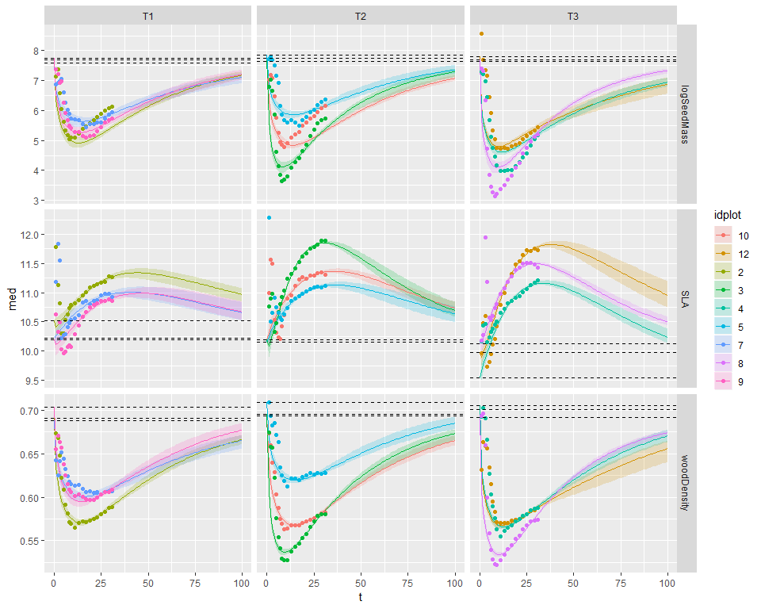

### Parameters value

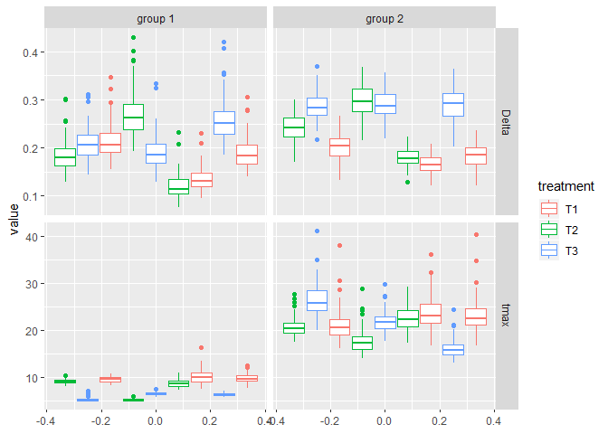

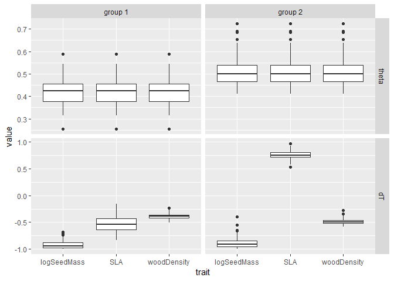